# Task 1: Princple Components Analysis of USDA Nutritional Information for Dairy Products

Mari Herbst

2/11/2022

# Introduction

In this report I will explore whether there is correlation between nutritional indices for dairy products. The data comes from USDA’s National Nutritional Database. I will use Principle Components Analysis to investigate how the energy (kcal), protein (g), fat (g), carbs (g), sugar (g), and fiber (g) content of these dairy products relate to each other. I will use the PC analysis to create a biplot that demonstrates magnitude and direction of correspondence between nutritional indices as well as a screeplot that shows the amount of variance explained by each principle component.

# Data

## Citation

U.S. Department of Agriculture, Agricultural Research Service. FoodData Central, 2019. fdc.nal.usda.gov.

## Wrangling

```r
# read in data using here to create a system agnostic file path
usda_nutrients <- read_csv(here("data", "usda_nutrients.csv"))
```

```r
# create a function to indicate NOT in
"%!in%" <- Negate("%in%")
```

```r
# wrangle data
usda_dairy <- usda_nutrients %>%
  janitor::clean_names() %>% # make column names easier to work with
  filter(food_group == "Dairy and Egg Products") %>% # select only dairy and egg data
  drop_na(descrip, energy_kcal, protein_g, fat_g, carb_g, sugar_g, fiber_g) %>% # drop NA values in columns that will be analyzed
  separate(col = descrip, # separate the column descrip
           into = c("category", "details"), # into two columns
           sep = ",", # separate at the first comma
           extra = "merge", # if there are multiple, merge them into the second column
           remove = TRUE) %>% # remove original column "descrip"
  mutate(category = ifelse(str_detect(category, "KRAFT"), "Kraft", category)) %>% # replace category observations that contain the brand name Kraft with just "Kraft"
  mutate(category = ifelse(str_detect(category, "Cheese"), "Cheese", category)) %>% # replace observations that contain the word cheese with simply "Cheese"
  mutate(category = ifelse(str_detect(category, "Cream"), "Cream", category)) %>% # same for cream with "cream"
  mutate(category = ifelse(str_detect(category, "Queso"), "Cheese", category)) %>% # and queso with "cheese"
  mutate(category = ifelse(str_detect(category, "Parmesan cheese topping"), "Cheese", category)) %>% # and Parmesan topping with "cheese"
  mutate(category = ifelse(str_detect(category, "Ice cream"), "Ice cream", category)) %>% # and ice cream with "ice cream"
  filter(category %!in% c("Eggs", "Egg substitute", "Egg", "Egg Mix", "Protein supplement", "Sour dressing", "USDA Commodity", "Nutritional supplement for people with diabetes", "Reddi Wip Fat Free Whipped Topping")) %>% # remove observations from some categories
  select(-(id:short_descrip), -(vit_a_mcg:zinc_usrda), -(details:scientific_name)) # remove irrelevant columns
```

# PCA

```r
# run a PCA on the data
dairy_pca <- usda_dairy %>%
  select(-category) %>% # remove columns that won't be included in analysis
  scale() %>% # scale the data so that values are comparable
  prcomp()
```

## Biplot

```r
colnames(usda_dairy) <- c("category", "energy (kcal)", "protein (g)", "fat (g)", "carbs (g)", "sugar (g)", "fiber (g)")
```

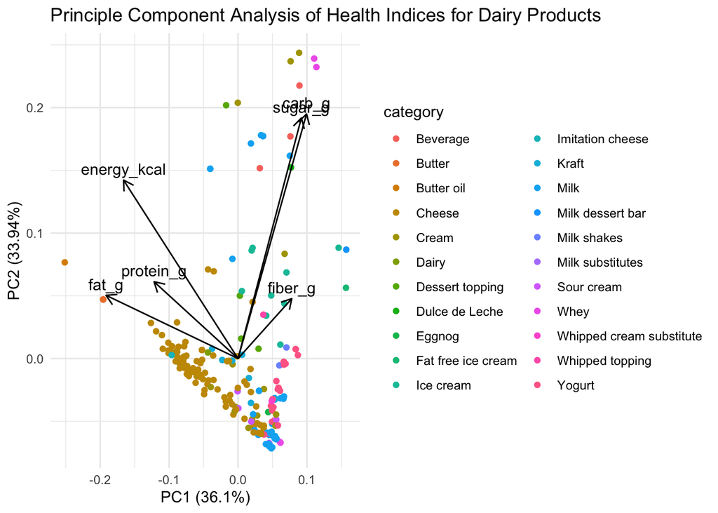

```r
autoplot(dairy_pca,
         data = usda_dairy,
         loadings = TRUE, # arrows
         colour = "category",
         loadings.label = TRUE, # label arrows
         loadings.colour = "black", # change arrow color
         loadings.label.colour = "black", # change arrow label color
         loadings.label.vjust = -0.5) + # adjust arrow label position
  labs(title = "Principle Component Analysis of Health Indices for Dairy Products") + # add figure title
  theme_minimal() # add theme
```

**Figure 1**: A principle component analysis of nutritional indices of dairy products as recorded by the USDA. Arrows indicate the magnitude and direction of each factors’ influence on the principle components. Arrows that are close together indicate a strong correlation between the indices; right angles between arrows indicate the indices are not correlated.

## Screeplot

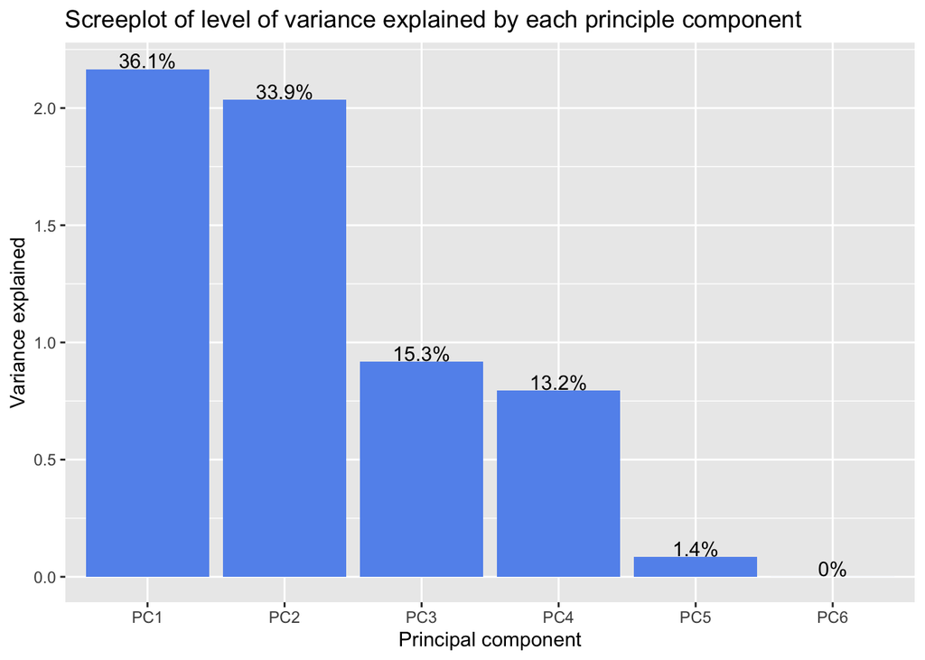

```r
sd_vec <- dairy_pca$sdev # extract standard deviations into a vector

var_vec <- sd_vec^2 # calculate variance from SD

pc_names <- colnames(dairy_pca$rotation) # quickly get column names from pca object

pct_explained_df <- data.frame(v = var_vec, # put vectors into a df as column values
                               pct_v = var_vec/sum(var_vec), # calculate percentages of variance by PC
                               pc = fct_inorder(pc_names)) %>% # order the percentages
  mutate(pct_lbl = paste0(round(pct_v * 100, 1),"%")) # paste0 makes it so there are no spaces between the value and the percent sign

ggplot(data = pct_explained_df,
       aes(x = pc, y = v)) +
  geom_col(fill= "cornflowerblue") + # add color
  geom_text(aes(label = pct_lbl), vjust = 0, nudge_y = 0.005) + # add labels with % variance explained by each one
  labs(x = "Principal component", y = "Variance explained",
       title = "Screeplot of level of variance explained by each principle component")
```

**Figure 2**: This screeplot shows the variance that is accounted for by each principle component from the PCA of the USDA dairy data. The combined variance shown combines to 100%, with each descending principle components explaining a lower amount of variance than the principle component before it.

# Takeaways

The PC1 and PC2 principle components only account for around 70% of the variance in this data, so much of the variance in this nutritional data is still not accounted for. Based on the screeplot, we can see that it might be worthwhile to add PC3 into this analysis to explain a larger percentage of the variance. However, the information we have from PC1 and PC2 indicates that:

- Carbs and sugar content are highly positively correlated.
- Carbs and sugar content are not correlated with fat content.
- Fiber content and energy content are not correlated.
- Protein, fat, and energy content are somewhat positively correlated.